```python
import matplotlib.pyplot as plt
import numpy as np
import os
import tensorflow as tf
from tensorflow import keras
from tensorflow.keras import preprocessing
from tensorflow.keras.preprocessing import image_dataset_from_directory
```

```python
print(tf.__version__)
```

```
2.5.0
```

# Loading SIPI Dataset

SIPI dataset was preprocessed using prepare_dataset notebook, so these three folders already contain Detritus/Non-Detritus images.

```python
DatasetName = 'DatasetSIPI-NoShadow'

train_dir = DatasetName+'/train'
validation_dir =  DatasetName+'/val'
test_dir = DatasetName+'/test'
```

```python
BATCH_SIZE = 32
IMG_SIZE = (160, 160)
```

The three datasets are loaded using keras preprocessing method *image_dataset_from_directory*. Both the batch size and the image size hyperparameters where tested using different values.

```python
train_dataset = image_dataset_from_directory(train_dir,
shuffle=True,
batch_size=BATCH_SIZE,
image_size=IMG_SIZE)

validation_dataset = image_dataset_from_directory(validation_dir,
shuffle=True,
batch_size=BATCH_SIZE,
image_size=IMG_SIZE)

test_dataset = image_dataset_from_directory(test_dir,
shuffle=True,
batch_size=BATCH_SIZE,
image_size=IMG_SIZE)
```

```
Found 30474 files belonging to 2 classes.
Found 6529 files belonging to 2 classes.
Found 6530 files belonging to 2 classes.
```

# Training

```python
# Hyperparamers to be used in all models
base_learning_rate = 0.0001
IMG_SHAPE = IMG_SIZE + (3,)
TRAINING_EPOCHS = 40
```

# MobileNet model

A MobileNet model is loaded and modified so it can be used to predict Detritus images..

```python
mobile_base_model = tf.keras.applications.MobileNetV2(input_shape=IMG_SHAPE,
                                               include_top=False,
                                               weights=None)
```

```python
image_batch, label_batch = next(iter(train_dataset))
feature_batch = mobile_base_model(image_batch)
print(feature_batch.shape)
```

```
(32, 5, 5, 1280)
```

```python
global_average_layer = tf.keras.layers.GlobalAveragePooling2D()
feature_batch_average = global_average_layer(feature_batch)
print(feature_batch_average.shape)
```

```
(32, 1280)
```

```python
prediction_layer = tf.keras.layers.Dense(1)
prediction_batch = prediction_layer(feature_batch_average)
print(prediction_batch.shape)
```

```
(32, 1)
```

```python
preprocess_input = tf.keras.applications.mobilenet_v2.preprocess_input

inputs = tf.keras.Input(shape=(160, 160, 3))
x = preprocess_input(inputs)
x = mobile_base_model(x)
x = global_average_layer(x)
outputs = prediction_layer(x)
mobilenet_model = tf.keras.Model(inputs, outputs)
```

# DenseNet model

```python
dense_base_model = tf.keras.applications.DenseNet201(input_shape=IMG_SHAPE,
                                               include_top=False,
                                               weights=None)
```

```python
preprocess_input = tf.keras.applications.densenet.preprocess_input
global_average_layer = tf.keras.layers.GlobalAveragePooling2D()
prediction_layer = tf.keras.layers.Dense(1)

inputs = tf.keras.Input(shape=(160, 160, 3))
x = preprocess_input(inputs)
x = dense_base_model(x)
x = global_average_layer(x)
outputs = prediction_layer(x)
densenet_model = tf.keras.Model(inputs, outputs)
```

# VGG model

```python
vgg_base_model = tf.keras.applications.VGG19(input_shape=IMG_SHAPE,
                                               include_top=False,
                                               weights=None)
```

```python
preprocess_input = tf.keras.applications.vgg19.preprocess_input
global_average_layer = tf.keras.layers.GlobalAveragePooling2D()
prediction_layer = tf.keras.layers.Dense(1)

inputs = tf.keras.Input(shape=(160, 160, 3))
x = preprocess_input(inputs)
x = vgg_base_model(x)
x = global_average_layer(x)
outputs = prediction_layer(x)
vgg_model = tf.keras.Model(inputs, outputs)
```

# Inception Resnet model

```python
inception_base_model = tf.keras.applications.InceptionResNetV2(input_shape=IMG_SHAPE,
                                               include_top=False,
                                               weights=None)
```

```python
preprocess_input = tf.keras.applications.inception_resnet_v2.preprocess_input
global_average_layer = tf.keras.layers.GlobalAveragePooling2D()
prediction_layer = tf.keras.layers.Dense(1)

inputs = tf.keras.Input(shape=(160, 160, 3))
x = preprocess_input(inputs)
x = inception_base_model(x)
x = global_average_layer(x)
outputs = prediction_layer(x)
inception_resnet_model = tf.keras.Model(inputs, outputs)
```

# Training models

```python
def train_model(model, epochs):
    print("Training model, epochs: ", epochs)
    model.compile(optimizer=tf.keras.optimizers.Adam(learning_rate=base_learning_rate),
              loss=tf.keras.losses.BinaryCrossentropy(from_logits=True),
              metrics=['accuracy'])

    history = model.fit(train_dataset,
                    epochs=epochs,
                    validation_data=validation_dataset)

    acc = history.history['accuracy']
    val_acc = history.history['val_accuracy']

    training_loss = history.history['loss']
    val_loss = history.history['val_loss']

    loss, accuracy = model.evaluate(test_dataset)
    print('Test accuracy :', accuracy)

    return acc, val_acc, training_loss, val_loss
```

```python
def show_plot(acc, val_acc, loss, val_loss):
    plt.figure(figsize=(8, 8))
    plt.subplot(2, 1, 1)
    plt.plot(acc, label='Training Accuracy')
    plt.plot(val_acc, label='Validation Accuracy')
    plt.legend(loc='lower right')
    plt.ylabel('Accuracy')
    plt.ylim([min(plt.ylim()),1])
    plt.title('Training and Validation Accuracy')

    plt.subplot(2, 1, 2)
    plt.plot(loss, label='Training Loss')
    plt.plot(val_loss, label='Validation Loss')
    plt.legend(loc='upper right')
    plt.ylabel('Cross Entropy')
    plt.ylim([0,1.0])
    plt.title('Training and Validation Loss')
    plt.xlabel('epoch')
    plt.show()
```

```
Training model, epochs:  40
Test accuracy : 0.888361394405365
```

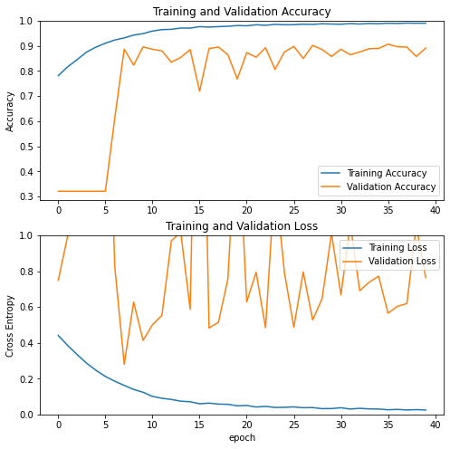

```python
acc, val_acc, loss, val_loss = train_model(mobilenet_model, TRAINING_EPOCHS)
show_plot(acc, val_acc, loss, val_loss)
```

```
Training model, epochs:  40
Test accuracy : 0.915773332118988
```

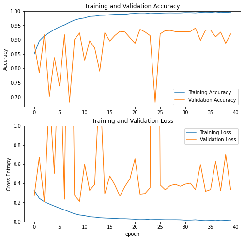

```python
acc, val_acc, loss, val_loss = train_model(densenet_model, TRAINING_EPOCHS)
show_plot(acc, val_acc, loss, val_loss)
```

```
Training model, epochs:  40
Test accuracy : 0.9343032240867615
```

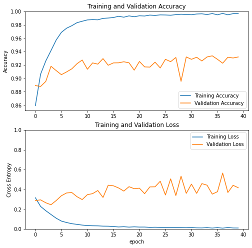

```python
acc, val_acc, loss, val_loss = train_model(inception_resnet_model, TRAINING_EPOCHS)
show_plot(acc, val_acc, loss, val_loss)
```

After comparing them we choose MobileNet as it demands a smaller number of parameters to train. We use techniques in order to improve Training and Validation accuracy.